# 老忠實案件與討論

中山大學管理學院 第20組

2019-04-02 02:27:40

### 老忠實噴泉等待時間

```r
library("dplyr")
```

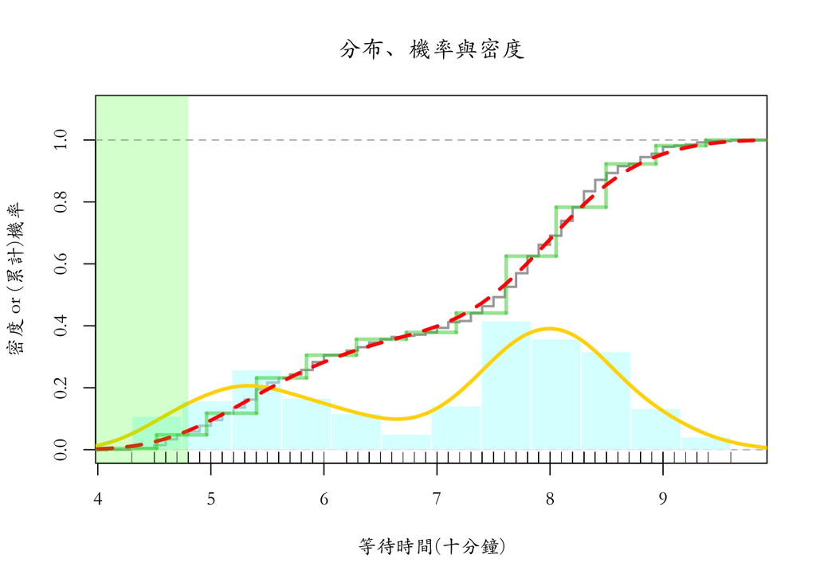

```r
par(family="STKaiti")
D = faithful$waiting*0.1  # copy to a short name

# Frame
plot(0,0,xlim=c(4.2,9.7),ylim=c(0,1.1),xlab="等待時間(十分鐘)",
     ylab="密度 or (累計)機率", main="分布、機率與密度")
abline(h=1, col='lightgray', lwd=0.25, lty=2)
par(family="STKaiti")

# Empirical PDF #機率密度函數
rug(D)

# Empirical(實證) CDF #累計機率函數
plot(ecdf(D), cex=0, verticals=T, lwd=2, col='darkgray', add=T)

# Histogram PDF
Bins = 12                             # no. bins
bx = seq(min(D), max(D), length=Bins+1) # break sequence
hist(D, col="#B3FFFF7F", border="white",
     freq=F, breaks=bx, add=T)
abline(h=0, col='lightgray', lwd=0.25)

# Histogram CDF
adj = (bx[2] - bx[1])/2
steps = stepfun(bx-adj, c(0, sapply(bx, function(b) mean(D <= b))))
plot(steps, cex=0, col='#33CC337F', lwd=3, lty=1, add=T)

# Smooth PDF ＃平滑機率密度函數
Adjust = 0.8    # bandwidth adjustment頻寬 #小：複雜;大：簡單
DEN = density(D, adjust = Adjust)
lines(DEN, col='gold', lwd=3)

# Smooth CDF
# 平滑線的x,y作為參數，後面照抄。
PDF = approxfun(DEN$x, DEN$y, yleft=0, yright=0)
x = seq(4,10,0.1) #視情況更改範圍

#integrate積分。積分算出曲線下面積。
y = sapply(x, function(i) integrate(PDF, -Inf, i)$value)
lines(x, y, col='red', lwd=3, lty=2)

# Mark Range
x1 = 3.8; x2 = 4.8
rect(x1,-0.1,x2,1.2,col= rgb(0,1,0,alpha=0.2),border=NA)
```

```r
# x = seq(x1, x2, length=100)
# polygon(c(x, x2, x1),  c(PDF(x), 0, 0), col="#FF99003F", border=NA)
# Calculate Probability
(integrate(PDF, x1, x2)$value)
```

```
[1] 0.060821
```

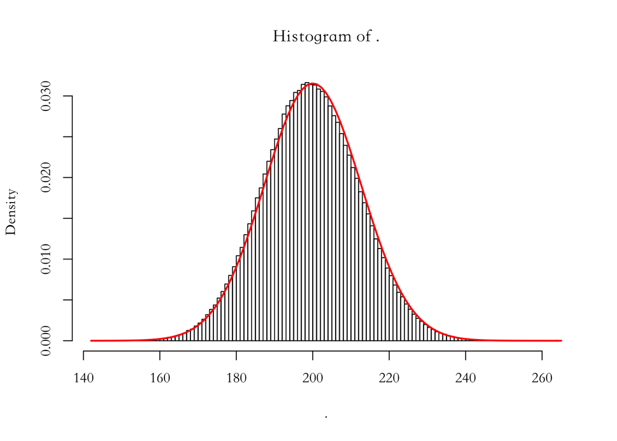

```r
###############################
rbinom(1000000, 1000, 0.2) %>% hist(breaks=100,freq=F)
curve(dnorm(x,mean=200,sd=sqrt(160)), col='red', lwd=2, add=T)
```

🗿 問題討論：  
【A.選擇方法】  
■ 我們為甚麼需要隨機變數？ 什麼時候我們需要用到隨機變數？  
Ans:因為隨機實驗每次產生的結果未必相同，且我們無法取得所有母體資料時，我們需要對他做預測時即可使用隨機變數、來紀錄。  
■ 隨機變數沒有固定的值，那我們要如何做計算呢？  
Ans:可以用頻率、機率、密度來表達隨機變數的分布，然後轉換成函數以後對分布做計算。  
■ 我們可以用直方圖或數值標記來估計噴發時間落在某一區間的機率嗎？  
Ans:可以，計算區間內所發生的次數占全部次數的比例。。  
■ 直方圖(histogram)也可以當作一種模型嗎？ 數值標記(rug)呢？  
Ans:可以，模型可幫助我們做預測，而直方圖所提供給我們的機率提供我們做下一次的預測，但用數值標記是用真實時間點來做模型，容易發生over fitting的情形。？  
■ 直方圖和平滑模型哪一個比較適合用來表示噴發時間的分布？ 為甚麼？  
Ans:平滑模型比較適合，因為因為直方圖的複雜度教高，且容易產生量化誤差。  
■ 用數值標記來預測噴發時間會比用直方圖「準」嗎？ 「準」是什麼意思呢？  
Ans:不一定，數值標記雖然是很準確的數字，但用在預測上反而會over fitting，因此不適合用在預測。準的意思是去描述估計值與實際值誤差是否相近。

【B.調整參數】調整一下模型參數的滑桿 …  
■ 你覺得最合適的直方圖欄數(`support/binwidth`)是？ 為甚麼？  
Ans:16，這時候的直方圖起伏較為規律，像多個常態分布排在一起。 ■ 最合適的平滑模型頻寬(`bandwidth`)呢？  
Ans:當bandwidth=0.7時較接近常態。  
■ 調高欄寬和頻寬會讓模型變複雜，還是變簡單呢？  
Ans: 直方圖變較複雜，而平滑模型則變簡單。  
■ 模型越複雜，它跟實際值之間的誤差是越大、還是越小？  
Ans:數值越精確，所以誤差越小。  
■ 那麼，越複雜的模型就會越準，對嗎？  
Ans:不一定，越複雜的模型表示與原本資料越相近，也容易overfitting，不代表預測的越準。  
【C.建立模型、估計機率】  
請從課堂筆記的程式碼找出來 …  
■ 從變數向量(`D`)求出機率密度曲線(`DEN`)

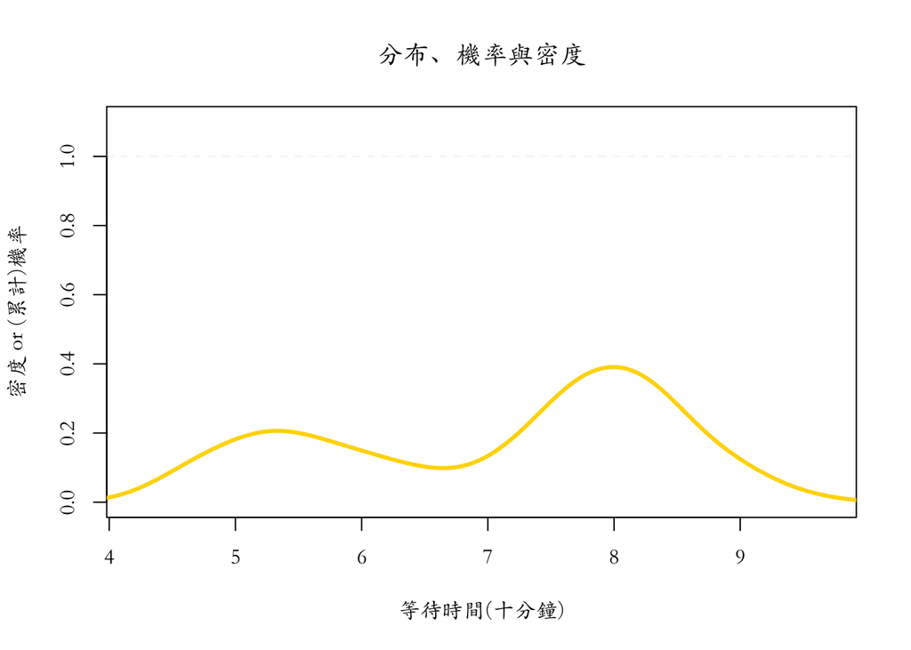

```r
# Smooth PDF ＃平滑機率密度函數
# Frame
plot(0,0,xlim=c(4.2,9.7),ylim=c(0,1.1),xlab="等待時間(十分鐘)",
     ylab="密度 or (累計)機率", main="分布、機率與密度")
abline(h=1, col='lightgray', lwd=0.25, lty=2)
Adjust = 0.8    # bandwidth adjustment
DEN = density(D, adjust = Adjust)
lines(DEN, col='gold', lwd=3)
```

■ 將機率密度曲線(`DEN`)轉換成機率密度函數(`PDF`)

```r
# Smooth CDF
PDF = approxfun(DEN$x, DEN$y, yleft=0, yright=0)  # 平滑線的x,y作為參數。
```

■ 對機率密度函數(`PDF`)做積分，算出機率(`PROB`)

```r
x = seq(4,10,0.1)  #視情況更改範圍 #integrate積分。積分算出曲線下面積。
y = sapply(x, function(i) integrate(PDF, -Inf, i)$value)
```

這三行程式，然後…  
■ 將頻寬調整參數(`adjust`)設為`1`，算出「等待時間」落在80到90之間的機率

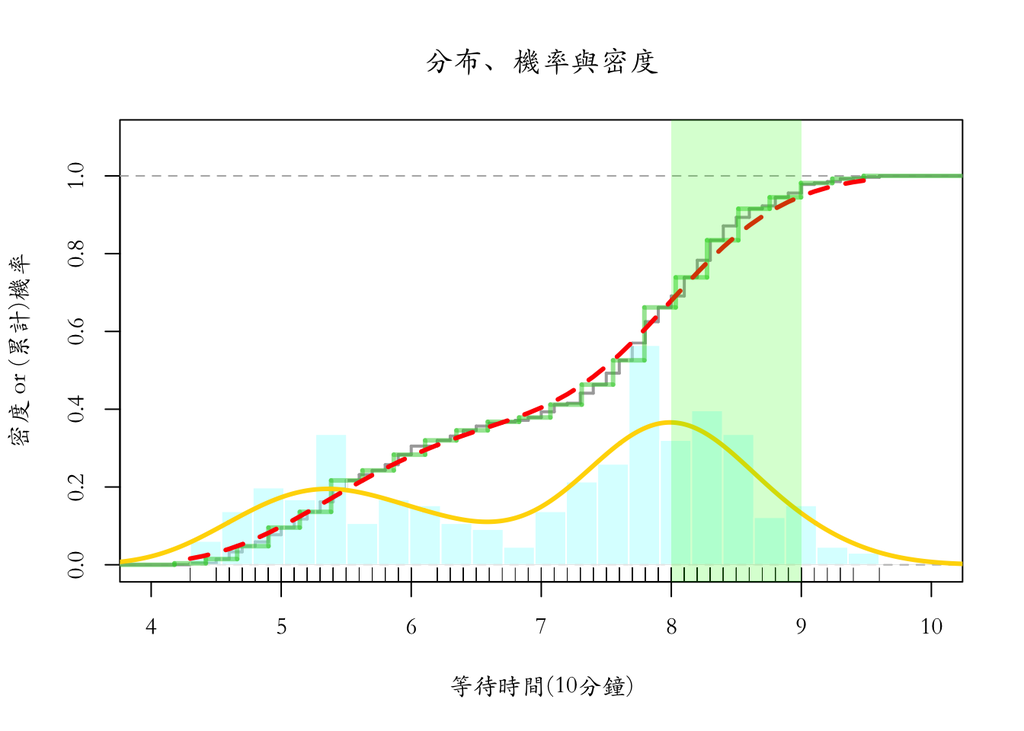

```r
par(family="STKaiti")
D = (faithful$waiting)/10  # copy to a short name
# Frame
plot(0,0,xlim=c(4,10),ylim=c(0,1.1),xlab="等待時間(10分鐘)",
     ylab="密度 or (累計)機率", main="分布、機率與密度")
abline(h=1, col='lightgray', lwd=0.25, lty=2)

# Empirical PDF
rug(D)
# Empirical CDF
plot(ecdf(D), cex=0, verticals=T, lwd=2, col='darkgray', add=T)

# Histogram PDF
Bins = 23                            # no. bins
bx = seq(min(D), max(D), length=Bins) # break sequence
hist(D, col="#B3FFFF7F", border="white", ylim=c(0,1.1),
     freq=F, breaks=bx, add=T)
abline(h=0, col='lightgray', lwd=0.25)
# Histogram CDF
adj = (bx[2] - bx[1])/2
steps = stepfun(bx-adj, c(0, sapply(bx, function(b) mean(D <= b))))
plot(steps, cex=0, col='#33CC337F', lwd=3, lty=1, add=T)

# Smooth PDF
Adjust = 1    # bandwidth adjustment
DEN = density(D, adjust = Adjust)
lines(DEN, col='gold', lwd=3)
# Smooth CDF
PDF = approxfun(DEN$x, DEN$y, yleft=0, yright=0)
x = seq(4.3,9.6,0.1)
y = sapply(x, function(i) integrate(PDF, -Inf, i)$value)
lines(x, y, col='red', lwd=3, lty=2)

# Mark Range
x1 = 8; x2 = 9
rect(x1,-0.1,x2,1.2,col= rgb(0,1,0,alpha=0.2),border=NA)
```

```r
# x = seq(x1, x2, length=100)
# polygon(c(x, x2, x1),  c(PDF(x), 0, 0), col="#FF99003F", border=NA)
# Calculate Probability
(integrate(PDF, x1, x2)$value)  # Ans:0.26851
```

```
[1] 0.26851
```

■ 將頻寬調整參數設為`0.5`，算出等待時間落在80到90之間的機率

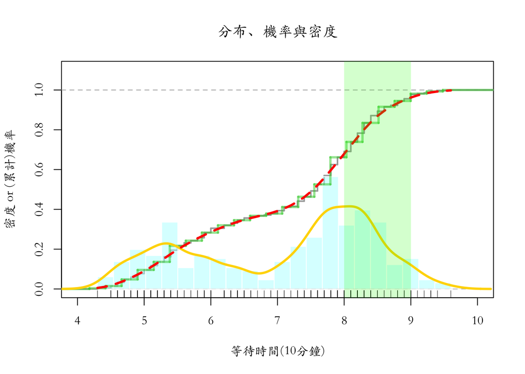

```r
par(family="STKaiti")
D = (faithful$waiting)/10  # copy to a short name

# Frame
plot(0,0,xlim=c(4,10),ylim=c(0,1.1),xlab="等待時間(10分鐘)",
     ylab="密度 or (累計)機率", main="分布、機率與密度")
abline(h=1, col='lightgray', lwd=0.25, lty=2)

# Empirical PDF
rug(D)
# Empirical CDF
plot(ecdf(D), cex=0, verticals=T, lwd=2, col='darkgray', add=T)

# Histogram PDF
Bins = 23                            # no. bins
bx = seq(min(D), max(D), length=Bins) # break sequence
hist(D, col="#B3FFFF7F", border="white", ylim=c(0,1.1),
     freq=F, breaks=bx, add=T)
abline(h=0, col='lightgray', lwd=0.25)
# Histogram CDF
adj = (bx[2] - bx[1])/2
steps = stepfun(bx-adj, c(0, sapply(bx, function(b) mean(D <= b))))
plot(steps, cex=0, col='#33CC337F', lwd=3, lty=1, add=T)

# Smooth PDF
Adjust = 0.5    # bandwidth adjustment
DEN = density(D, adjust = Adjust)
lines(DEN, col='gold', lwd=3)
# Smooth CDF
PDF = approxfun(DEN$x, DEN$y, yleft=0, yright=0)
x = seq(4.3,9.6,0.1)
y = sapply(x, function(i) integrate(PDF, -Inf, i)$value)
lines(x, y, col='red', lwd=3, lty=2)

# Mark Range
x1 = 8; x2 = 9
rect(x1,-0.1,x2,1.2,col= rgb(0,1,0,alpha=0.2),border=NA)
```

```r
# x = seq(x1, x2, length=100)
# polygon(c(x, x2, x1),  c(PDF(x), 0, 0), col="#FF99003F", border=NA)
# Calculate Probability
(integrate(PDF, x1, x2)$value) # Ans:0.28275
```

```
[1] 0.28275
```

■ 算出來的機率比較高的就是比較好的模型，對嗎？ 為甚麼？  
Ans:不一定，算出來比較高的機率，只表示該模型越接近原本的資料，預測的話則不一定比較準。但是模型應該具有一般性(不能太複雜)，才可以較準確的估計其他資料。  
【D.預測與決策】  
假設有一個賭局，你可以花30元選定一個連續60秒的時段，如果老忠實下一次的噴發時間落在你指定的區間，你就可以贏到100元；請你使用頻寬為`0.5`的平滑密度模型 …  
■ 決定要不要參加這個賭局  
Ans:要，因為期望值比30大。  
■ 如果你參加的話，你要把噴發時間設定在哪一個區間呢？  
Ans:3.9~4.9區間  
■ 你設在這個區間的話，參加這個賭局的期望值是？  
Ans:70*0.477+(-30)*(1-0.477)=17.66元  
假如賭場老闆從零開始把每10秒鐘設為一個區間，每個區間的賭金是五塊錢 …

```r
Adjust = 0.6    # bandwidth adjustment
D = faithful$eruptions
DEN = density(D, adjust = Adjust)
PDF = approxfun(DEN$x, DEN$y, yleft=0, yright=0)

start = seq(0, (5.1-1/6), 1/6)
end = seq((0+1/6), 5.1, 1/6)
p = data.frame(start, end)
for(i in 1:30){
  p[i, 3] = integrate(PDF, start[i], end[i])$value}

orderlist = p[order(p$V3, decreasing = T),]
head(orderlist,9)
```

```
    start    end       V3
27 4.3333 4.5000 0.092936
26 4.1667 4.3333 0.087889
28 4.5000 4.6667 0.086198
12 1.8333 2.0000 0.075522
25 4.0000 4.1667 0.075353
13 2.0000 2.1667 0.067825
29 4.6667 4.8333 0.067067
11 1.6667 1.8333 0.059760
24 3.8333 4.0000 0.058301
```

■ 你要怎麼押注，才能獲得最高的期望值呢？  
Ans:在機率最高的前九個區間下注，可以獲得最高的利潤(期望值)。  
■ 你的賭金和期望值各是多少？  
Ans:賭金5*9=45元。期望值62.085元

```r
(95 * sum(orderlist[1:9, 3]) - 5 * (1 - sum(orderlist[1:9, 3])))
```

```
[1] 62.085
```

將獲利的期望值和賭金的比值稱為「期望投資報酬率」 …  
■ 「最大期望投資報酬率」和「最大期望報酬」的投資策略是一樣的嗎？  
Ans:不一樣，因為最大期望投資報酬率有考慮到投入的成本，但最大期望報酬則是只考慮最後得到的報酬。所以用最大期望投資報酬率是比較好的投資策略。  
■ 你認為哪一個策略目標比較好呢？ 為什麼？  
Ans:最大期望投資報酬率，因為即使最大期望報酬值很高，但不考慮投入成本，可能最後還是虧損。